# Review 2 and 3

## Predicting Premier league match results

#### The Premier League (sometimes referred to as the EPL – English Premier League – outside of the United Kingdom) launched in 1992, and quickly became the #### world’s most popular sports league. Consisting of 20 teams, each club plays their opponents twice in a season, one match home and the other one away,

#### equaling 38 matches during the course of the entire season that runs from August through May.

#### it has quickly grown to be one of the largest grossing sport leagues in the world

```r
library(zoo)
library(dplyr)
library(writexl)
library(magrittr)
library(GGally)
library(missForest)
library(plyr)
library(reshape2)
library(Metrics)
library(caret)
library(mice)
library(datarium)
library(MASS)
library(car)
```

```r
library(cowplot)
library(randomForest)
library(tidyverse)
library(caret)
library(rpart)
library(rpart.plot)
library(mlbench)
library(caTools)
library(ROSE)
library(imbalance)
library(e1071)
library(freqdist)
library(class)
library(caretEnsemble)
library(JOUSBoost)
library(plotrix)
library(lubridate)
library(ggrepel)
library(purrr)
library(kernlab)
library(skellam)
library(huxtable)
library(ggplot2)
library(tibble)
library(gridExtra)
```

#### Dataset - https://www.kaggle.com/irkaal/english-premier-league-results?select=results.csv

```r
d=read.csv("C:/Files/R datasets/results.csv")
head(d)
```

| Season | DateTime | HomeTeam | AwayTeam | FTHG | FTAG | FTR | HTHG | HTAG | HTR | Referee | HS | AS | HST | AST | HC | AC | HF | AF | HY | AY | HR | AR |
| --- | --- | --- | --- | --- | --- | --- | --- | --- | --- | --- | --- | --- | --- | --- | --- | --- | --- | --- | --- | --- | --- | --- |
| 1993-94 | 1993-08-14T00:00:00Z | Arsenal | Coventry | 0 | 3 | A |  |  |  |  |  |  |  |  |  |  |  |  |  |  |  |  |
| 1993-94 | 1993-08-14T00:00:00Z | Aston Villa | QPR | 4 | 1 | H |  |  |  |  |  |  |  |  |  |  |  |  |  |  |  |  |
| 1993-94 | 1993-08-14T00:00:00Z | Chelsea | Blackburn | 1 | 2 | A |  |  |  |  |  |  |  |  |  |  |  |  |  |  |  |  |
| 1993-94 | 1993-08-14T00:00:00Z | Liverpool | Sheffield Weds | 2 | 0 | H |  |  |  |  |  |  |  |  |  |  |  |  |  |  |  |  |
| 1993-94 | 1993-08-14T00:00:00Z | Man City | Leeds | 1 | 1 | D |  |  |  |  |  |  |  |  |  |  |  |  |  |  |  |  |
| 1993-94 | 1993-08-14T00:00:00Z | Newcastle | Tottenham | 0 | 1 | A |  |  |  |  |  |  |  |  |  |  |  |  |  |  |  |  |

```r
str(d)
```

```
## 'data.frame':    10710 obs. of  23 variables:
##  $ Season  : chr  "1993-94" "1993-94" "1993-94" "1993-94" ...
##  $ DateTime: chr  "1993-08-14T00:00:00Z" "1993-08-14T00:00:00Z" "1993-08-14T00:00:00Z" "1993-08-14T00:00:00Z" ...
##  $ HomeTeam: chr  "Arsenal" "Aston Villa" "Chelsea" "Liverpool" ...
##  $ AwayTeam: chr  "Coventry" "QPR" "Blackburn" "Sheffield Weds" ...
##  $ FTHG    : int  0 4 1 2 1 0 0 3 0 0 ...
##  $ FTAG    : int  3 1 2 0 1 1 3 1 2 2 ...
##  $ FTR     : chr  "A" "H" "A" "H" ...
##  $ HTHG    : int  NA NA NA NA NA NA NA NA NA NA ...
##  $ HTAG    : int  NA NA NA NA NA NA NA NA NA NA ...
##  $ HTR     : chr  NA NA NA NA ...
##  $ Referee : chr  NA NA NA NA ...
##  $ HS      : int  NA NA NA NA NA NA NA NA NA NA ...
##  $ AS      : int  NA NA NA NA NA NA NA NA NA NA ...
##  $ HST     : int  NA NA NA NA NA NA NA NA NA NA ...
##  $ AST     : int  NA NA NA NA NA NA NA NA NA NA ...
##  $ HC      : int  NA NA NA NA NA NA NA NA NA NA ...
##  $ AC      : int  NA NA NA NA NA NA NA NA NA NA ...
##  $ HF      : int  NA NA NA NA NA NA NA NA NA NA ...
##  $ AF      : int  NA NA NA NA NA NA NA NA NA NA ...
##  $ HY      : int  NA NA NA NA NA NA NA NA NA NA ...
##  $ AY      : int  NA NA NA NA NA NA NA NA NA NA ...
##  $ HR      : int  NA NA NA NA NA NA NA NA NA NA ...
##  $ AR      : int  NA NA NA NA NA NA NA NA NA NA ...
```

```r
summary(d)
```

```
##     Season            DateTime           HomeTeam           AwayTeam
##  Length:10710       Length:10710       Length:10710       Length:10710
##  Class :character   Class :character   Class :character   Class :character
##  Mode  :character   Mode  :character   Mode  :character   Mode  :character
##
##
##
##
##       FTHG           FTAG           FTR                 HTHG
##  Min.   :0.00   Min.   :0.000   Length:10710       Min.   :0.0000
##  1st Qu.:1.00   1st Qu.:0.000   Class :character   1st Qu.:0.0000
##  Median :1.00   Median :1.000   Mode  :character   Median :0.0000
##  Mean   :1.52   Mean   :1.133                      Mean   :0.6852
##  3rd Qu.:2.00   3rd Qu.:2.000                      3rd Qu.:1.0000
##  Max.   :9.00   Max.   :9.000                      Max.   :5.0000
##                                                    NA's   :924
##       HTAG            HTR              Referee                HS
##  Min.   :0.0000   Length:10710       Length:10710       Min.   : 0.00
##  1st Qu.:0.0000   Class :character   Class :character   1st Qu.:10.00
##  Median :0.0000   Mode  :character   Mode  :character   Median :13.00
##  Mean   :0.4966                                         Mean   :13.49
##  3rd Qu.:1.0000                                         3rd Qu.:17.00
##  Max.   :5.0000                                         Max.   :43.00
##  NA's   :924                                            NA's   :2824
##        AS             HST              AST               HC
##  Min.   : 0.00   Min.   : 0.000   Min.   : 0.000   Min.   : 0.000
##  1st Qu.: 7.00   1st Qu.: 4.000   1st Qu.: 3.000   1st Qu.: 4.000
##  Median :10.00   Median : 6.000   Median : 4.000   Median : 6.000
##  Mean   :10.58   Mean   : 6.189   Mean   : 4.798   Mean   : 6.106
##  3rd Qu.:13.00   3rd Qu.: 8.000   3rd Qu.: 6.000   3rd Qu.: 8.000
##  Max.   :30.00   Max.   :24.000   Max.   :20.000   Max.   :20.000
##  NA's   :2824    NA's   :2824     NA's   :2824     NA's   :2824
##        AC               HF              AF              HY
##  Min.   : 0.000   Min.   : 0.00   Min.   : 1.00   Min.   :0.000
##  1st Qu.: 3.000   1st Qu.: 9.00   1st Qu.: 9.00   1st Qu.:0.000
##  Median : 4.000   Median :11.00   Median :12.00   Median :1.000
##  Mean   : 4.776   Mean   :11.43   Mean   :11.96   Mean   :1.405
##  3rd Qu.: 6.000   3rd Qu.:14.00   3rd Qu.:14.00   3rd Qu.:2.000
##  Max.   :19.000   Max.   :33.00   Max.   :29.00   Max.   :7.000
##  NA's   :2824     NA's   :2824    NA's   :2824    NA's   :2824
##        AY              HR               AR
##  Min.   :0.000   Min.   :0.0000   Min.   :0.0000
##  1st Qu.:1.000   1st Qu.:0.0000   1st Qu.:0.0000
##  Median :2.000   Median :0.0000   Median :0.0000
##  Mean   :1.749   Mean   :0.0634   Mean   :0.0905
##  3rd Qu.:3.000   3rd Qu.:0.0000   3rd Qu.:0.0000
##  Max.   :9.000   Max.   :3.0000   Max.   :2.0000
##  NA's   :2824    NA's   :2824     NA's   :2824
```

## Defintion of the variables

| variable | Definition |
| --- | --- |
| FTR | Full time results |
| Season | season year |
| Date | data and time of match |
| FTHG | Full time home goals |
| FTAG | Full time away goals |
| HTR | half time result |
| Referee | Refree of the match |
| HTHG | Half time home goals |
| HTAG | half time away goals |
| HS | home shots on goal |
| AS | away shots on goal |
| HST | home shots on target |
| AST | away shots on target |
| HF | home fouls |
| AF | away fouls |
| HC | home corners |
| HY | home yellows |
| AY | away yellows |
| AR | away reds |
| HR | home reds |

## Cleaning the dataset

```r
d1=d
sapply(d, function(x) sum(is.na(x)))
```

```
##   Season DateTime HomeTeam AwayTeam     FTHG     FTAG      FTR     HTHG
##        0        0        0        0        0        0        0      924
##     HTAG      HTR  Referee       HS       AS      HST      AST       HC
##      924      924     2824     2824     2824     2824     2824     2824
##       AC       HF       AF       HY       AY       HR       AR
##     2824     2824     2824     2824     2824     2824     2824
```

```r
d1$HTR=ifelse(is.na(d1$HTR),d1$FTR,d1$HTR)
d1$HTHG=ifelse(is.na(d1$HTHG),d1$FTHG,d1$HTHG)
d1$HTAG=ifelse(is.na(d1$HTAG),d1$FTAG,d1$HTAG)
```

#### we assume that the half time results were the same as the full time results and replace them instead of averages which could skew the algorithm

```r
d1[] <- lapply(d1,function(x) replace(x,is.na(x), sample(x[!is.na(x)],sum(is.na(x)))))
any(is.na(d1))
```

```
## [1] FALSE
```

#### For the rest of the columns we used lapply and replace the rest of the NA values randomly with other values from the same column, hence we have now a clean dataset.

## Visualization

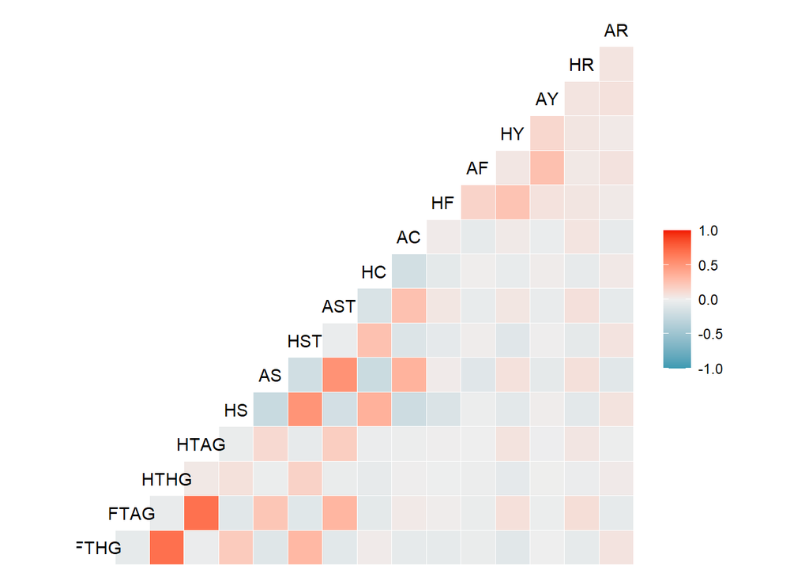

```r
ggcorr(d1)
```

## Which home team has the most cards and fouls

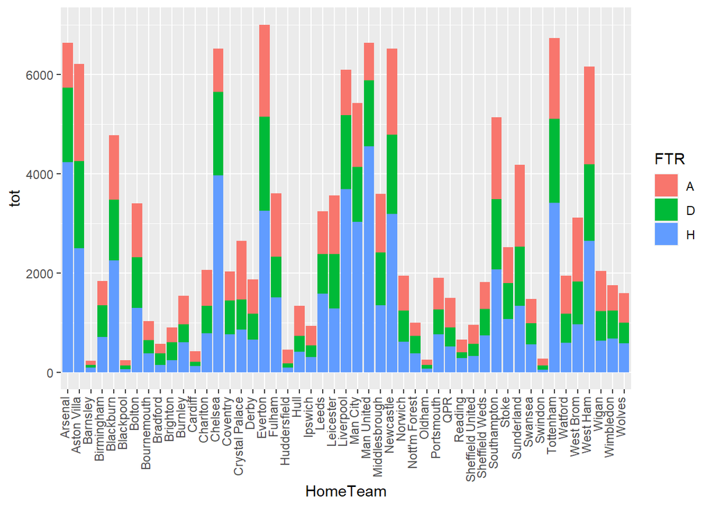

```r
d3=d1
d3$tot=d3$HR+d3$HY+d3$HF

ggplot(data=d3,aes(x=HomeTeam,y=tot,fill=FTR))+geom_bar(stat="identity")+theme(axis.text.x = element_text(angle = 90, vjust = 0.1, hjust=1))
```

### Everton has the most fouls and cards when they play at home

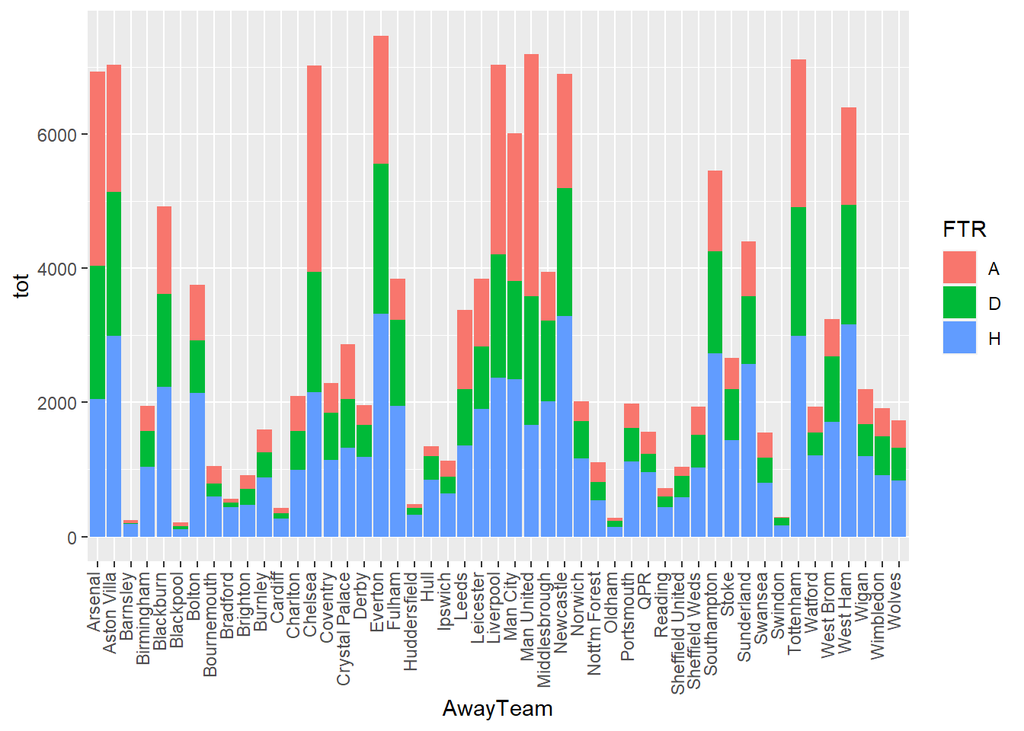

```r
d3=d1
d3$tot=d3$AR+d3$AY+d3$AF

ggplot(data=d3,aes(x=AwayTeam,y=tot,fill=FTR))+geom_bar(stat="identity")+theme(axis.text.x = element_text(angle = 90, vjust = 0.1, hjust=1))
```

#### Everton still has the most fouls and cards even when they play away

## Which teams came back from a losing position in the first half to a winning position in the second half while in home ground

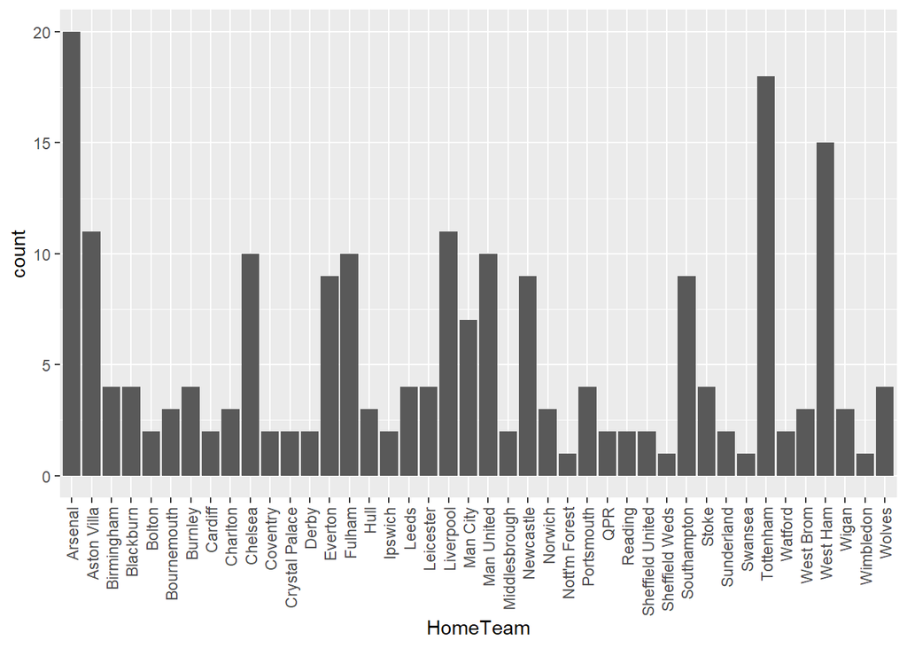

```r
k1=d1 %>% filter(HTR=="A") %>%
  filter(FTR=="H")
ggplot(data=k1,aes(x=HomeTeam))+geom_bar()+theme(axis.text.x = element_text(angle = 90, vjust = 0.5, hjust=1))
```

#### Hence aresnal is the team which had the most comebacks while in the homeground, with tottenham not too far away

## Which teams came back from a losing position in the first half to a winning position in the second half while in away ground

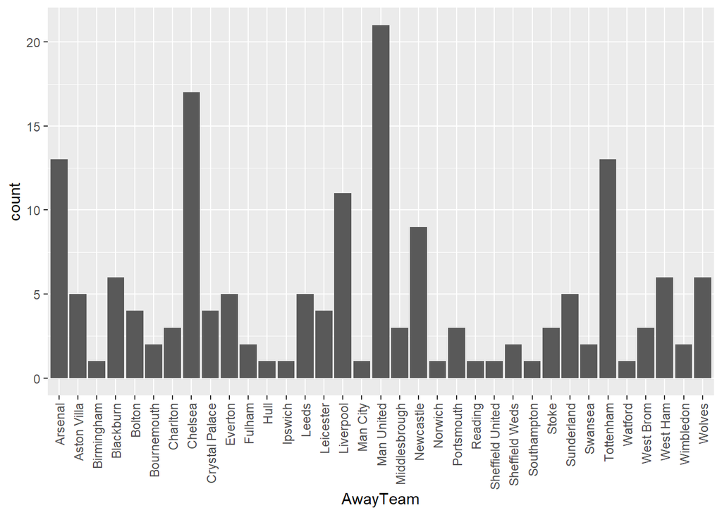

```r
k1=d1 %>% filter(HTR=="H") %>%
  filter(FTR=="A")

ggplot(data=k1,aes(x=AwayTeam))+geom_bar()+theme(axis.text.x = element_text(angle = 90, vjust = 0.5, hjust=1))
```

#### Hence Man united and chelsea reign supreme when it come to comeback victories while playing in an away ground

## Which teams bottled their lead in the first half while playing in homegames

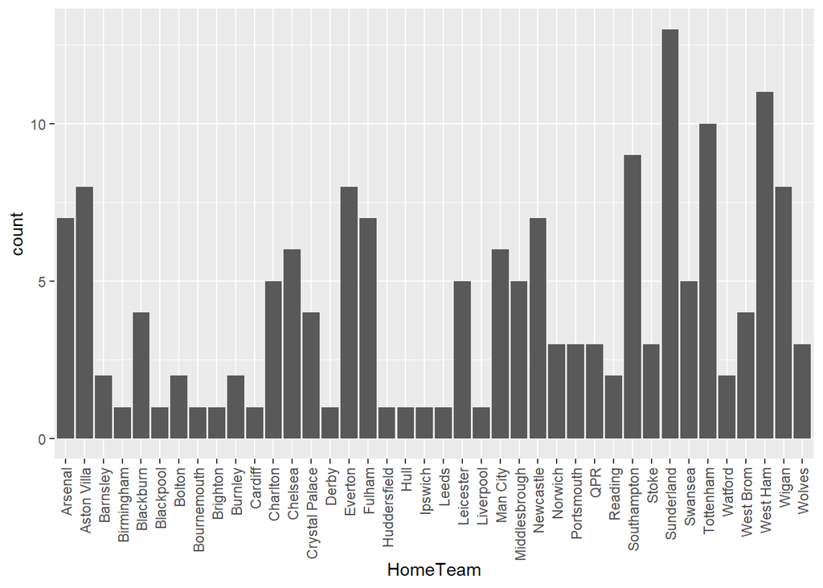

```r
fo=d1 %>% filter(HTR=="H") %>%
  filter(FTR=="A")
ggplot(data=fo,aes(x=HomeTeam))+geom_bar()+theme(axis.text.x = element_text(angle = 90, vjust = 0.5, hjust=1))
```

#### we can see that sunderland,westham and tottenham are relatively not good at holding a lead in home games

## Which teams bottled their lead in the first half while playing in Awaygames

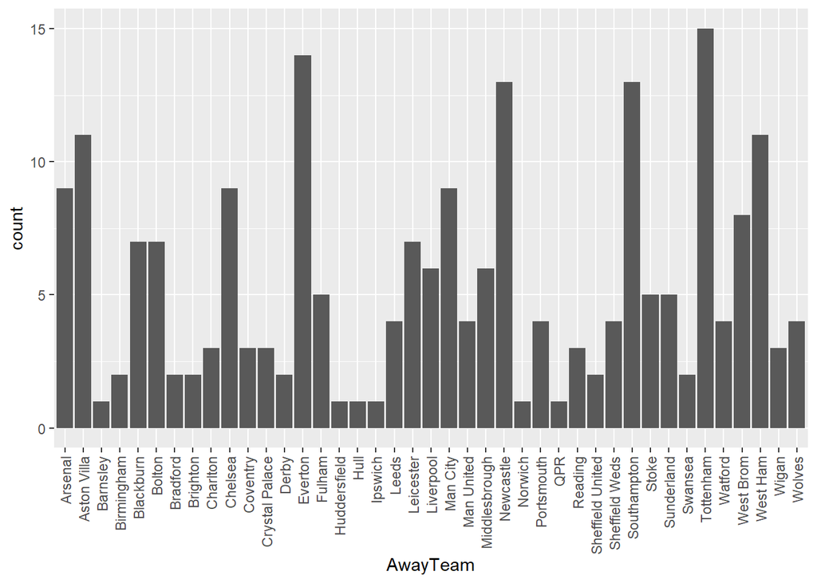

```r
fo=d1 %>% filter(HTR=="A") %>%
  filter(FTR=="H")
ggplot(data=fo,aes(x=AwayTeam))+geom_bar()+theme(axis.text.x = element_text(angle = 90, vjust = 0.5, hjust=1))
```

#### hence from the above plot we can see that tottenham(who are not the best at holding the lead), everton, southampton and newcastle are relatively bad at holding their lead after taking the advantage in the first half

## shots which were on target by home teams compared to the result of the game

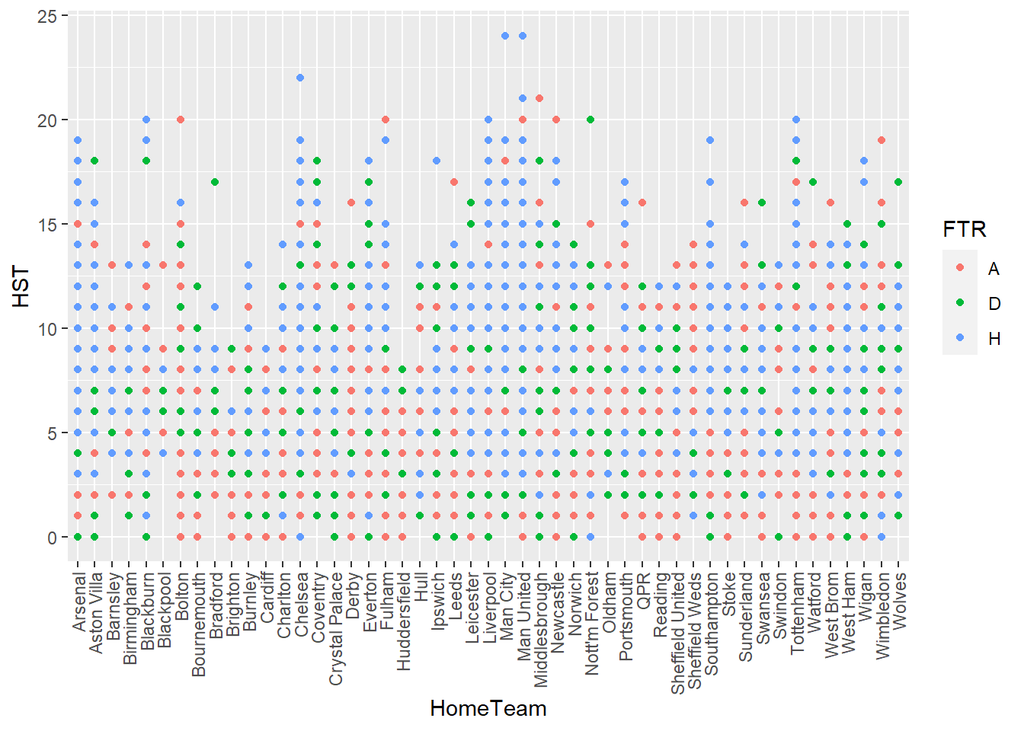

```r
ggplot(d1,aes(x=HomeTeam,y=HST,col=FTR))+geom_point(stat="identity")+theme(axis.text.x = element_text(angle = 90, vjust = 0.5, hjust=1))
```

## shots which were on target by away teams compared to the result of the game

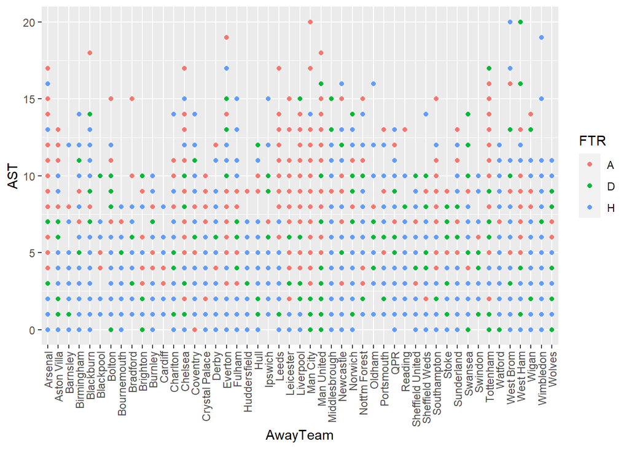

```r
ggplot(d1,aes(x=AwayTeam,y=AST,col=FTR))+geom_point(stat="identity")+theme(axis.text.x = element_text(angle = 90, vjust = 0.5, hjust=1))
```

## Did fouls affect the win for the hometeam

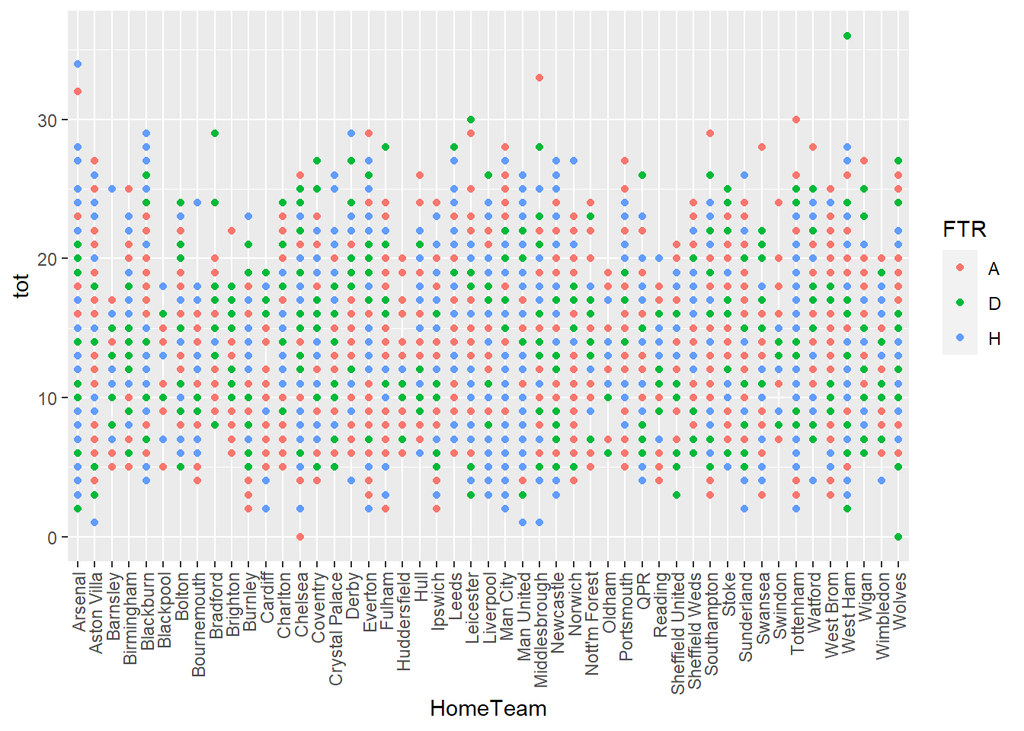

```r
tot=d1$HR+d1$HF+d1$HY
ggplot(d1,aes(x=HomeTeam,y=tot,col=FTR))+geom_point(stat="identity")+theme(axis.text.x = element_text(angle = 90, vjust = 0.5, hjust=1))
```

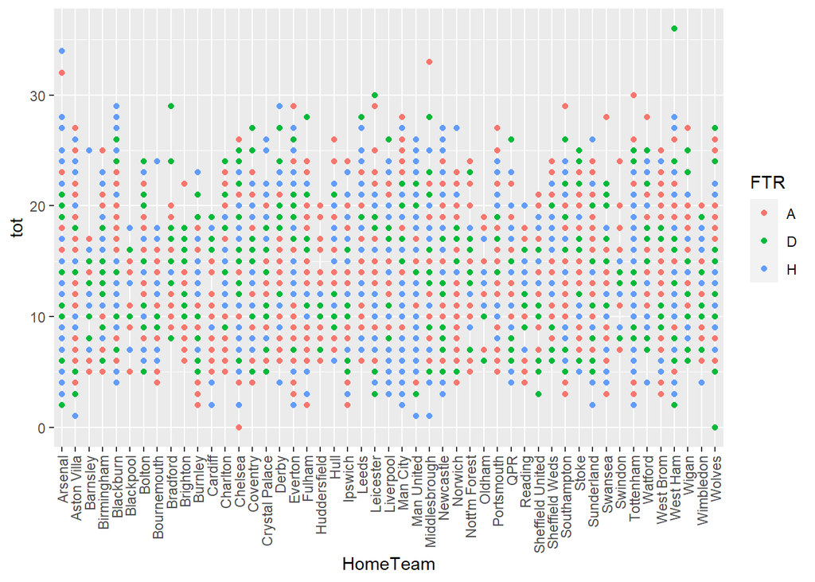

```r
tot=d1$HR+d1$HF+d1$HY
ggplot(d1,aes(x=HomeTeam,y=tot,col=FTR))+geom_point(stat="identity")+theme(axis.text.x = element_text(angle = 90, vjust = 0.5, hjust=1))
```

## Goals scored by home teams compared to the result of the game

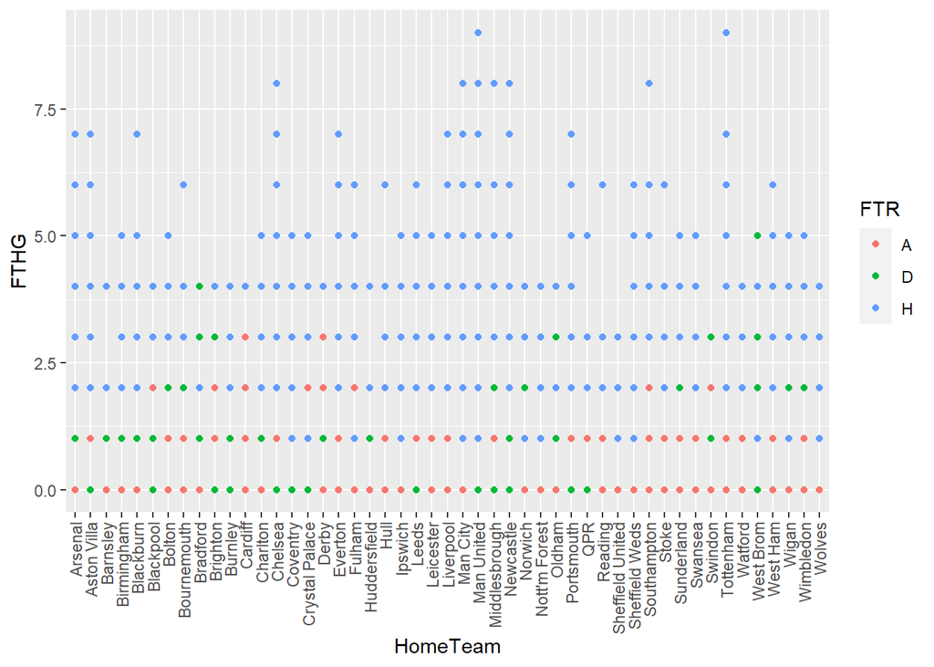

```r
ggplot(d1,aes(x=HomeTeam,y=FTHG,col=FTR))+geom_point(stat="identity")+theme(axis.text.x = element_text(angle = 90, vjust = 0.5, hjust=1))
```

#### Hence we can clearly see that there is a correalation, in the games where teams won their home games they had scored a high number of goals

## Goals scored by Awayteams compared to the result of the game

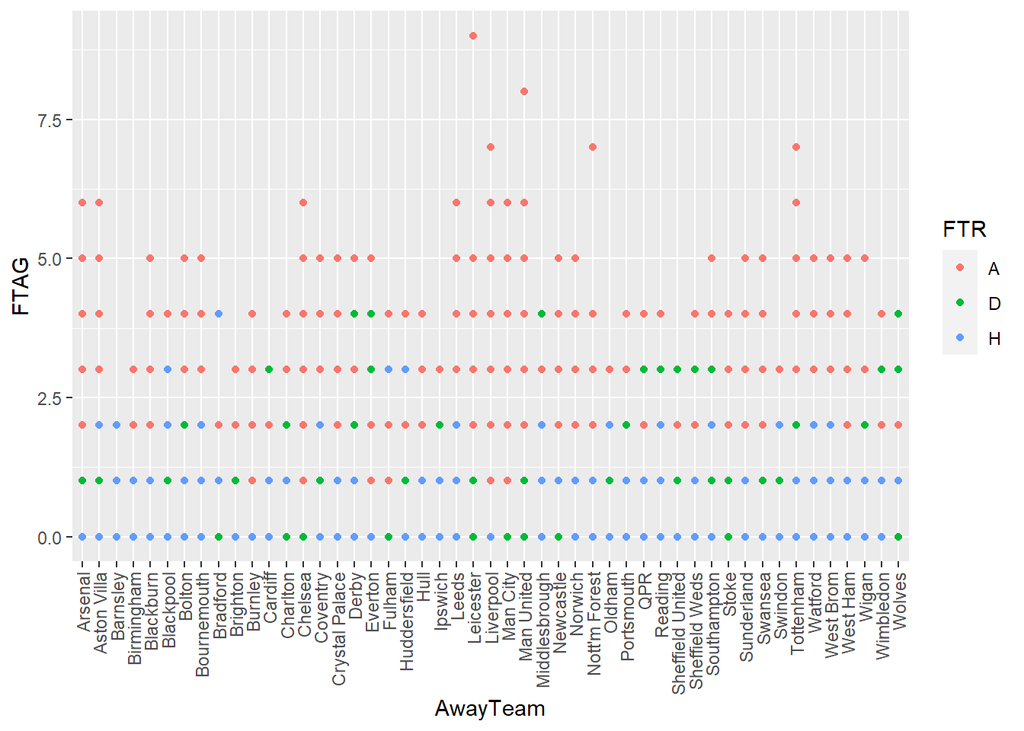

```r
ggplot(d1,aes(x=AwayTeam,y=FTAG,col=FTR))+geom_point(stat="identity")+theme(axis.text.x = element_text(angle = 90, vjust = 0.5, hjust=1))
```

#### Similarly in this we can see that Away teams have scored high goals for wins

#### Hence from the above two graphs we can conclude that there exists a correlation between teams scoring high number of goals and winning

## Prediction of full time results with the help of half time statistics

## Subsetting,factoring and dividing into test and train

```r
dmh=subset(d1,select=-c(FTHG,FTAG,Season,DateTime,Referee))
set.seed(420)
dmh$FTR=as.factor(dmh$FTR)
t=dmh$FTR %>%
  createDataPartition(p=0.8,list = FALSE)
tr=dmh[t,]
te=dmh[-t,]
```

## applying Random forest model

```r
set.seed(420)
mode=randomForest(FTR ~ ., data=tr,proximity=TRUE)
mode
```

```
##
## Call:
##  randomForest(formula = FTR ~ ., data = tr, proximity = TRUE)
##                Type of random forest: classification
##                      Number of trees: 500
## No. of variables tried at each split: 4
##
##         OOB estimate of  error rate: 34.37%
## Confusion matrix:
##      A   D    H class.error
## A 1624 456  331   0.3264206
## D  492 893  836   0.5979289
## H  230 600 3107   0.2108204
```

## increasing efficiency of mtry

```r
ov=vector(length=20)
for(i in 1:20){
  tempm=randomForest(FTR ~., data=tr,mtry=i,ntree=500)
  ov[i]=tempm$err.rate[nrow(tempm$err.rate),1]
}
ov
```

```
##  [1] 0.3603688 0.3448477 0.3464815 0.3451978 0.3471817 0.3477652 0.3475318
##  [8] 0.3495157 0.3483487 0.3485821 0.3483487 0.3496324 0.3463648 0.3509161
## [15] 0.3499825 0.3496324 0.3502159 0.3471817 0.3511495 0.3525499
```

```r
mfr=randomForest(FTR ~ ., data=tr,ntree=1000,mtry=4)
mfr
```

```
##
## Call:
##  randomForest(formula = FTR ~ ., data = tr, ntree = 1000, mtry = 4)
##                Type of random forest: classification
##                      Number of trees: 1000
## No. of variables tried at each split: 4
##
##         OOB estimate of  error rate: 34.54%
## Confusion matrix:
##      A   D    H class.error
## A 1611 468  332   0.3318125
## D  493 891  837   0.5988294
## H  237 593 3107   0.2108204
```

## Testing accuracy

```r
pc=mfr %>% predict(te,"class")
head(pc)
```

```
##  2 10 13 15 20 29
##  H  A  H  H  A  H
## Levels: A D H
```

```r
confusionMatrix(factor(pc),factor(te$FTR))
```

```
## Confusion Matrix and Statistics
##
##           Reference
## Prediction   A   D   H
##          A 403 123  64
##          D 130 216 135
##          H  69 216 785
##
## Overall Statistics
##
##                Accuracy : 0.6558
##                  95% CI : (0.6352, 0.6759)
##     No Information Rate : 0.4596
##     P-Value [Acc > NIR] : < 2.2e-16
##
##                   Kappa : 0.4575
##
##  Mcnemar's Test P-Value : 0.0002639
##
## Statistics by Class:
##
##                      Class: A Class: D Class: H
## Sensitivity            0.6694   0.3892   0.7978
## Specificity            0.8785   0.8329   0.7537
## Pos Pred Value         0.6831   0.4491   0.7336
## Neg Pred Value         0.8717   0.7958   0.8142
## Prevalence             0.2812   0.2592   0.4596
## Detection Rate         0.1882   0.1009   0.3667
## Detection Prevalence   0.2756   0.2247   0.4998
## Balanced Accuracy      0.7740   0.6111   0.7757
```

```r
acc = mean(pc == (te$FTR))
acc
```

```
## [1] 0.6557683
```

## linear regression model for full time home goals

```r
hg=lm(FTHG~HomeTeam+AwayTeam,data=d1)
summary(hg)
```

```
##
## Call:
## lm(formula = FTHG ~ HomeTeam + AwayTeam, data = d1)
##
## Residuals:
##     Min      1Q  Median      3Q     Max
## -2.9171 -0.9411 -0.1846  0.7308  7.0854
##
## Coefficients:
##                          Estimate Std. Error t value Pr(>|t|)
## (Intercept)               1.67846    0.07742  21.679  < 2e-16 ***
## HomeTeamAston Villa      -0.73745    0.07884  -9.353  < 2e-16 ***
## HomeTeamBarnsley         -0.69860    0.29085  -2.402 0.016326 *
## HomeTeamBirmingham       -0.78457    0.12095  -6.487 9.16e-11 ***
## HomeTeamBlackburn        -0.47256    0.08765  -5.391 7.15e-08 ***
## HomeTeamBlackpool        -0.42931    0.29082  -1.476 0.139925
## HomeTeamBolton           -0.71445    0.09606  -7.438 1.10e-13 ***
## HomeTeamBournemouth      -0.59890    0.13911  -4.305 1.68e-05 ***
## HomeTeamBradford         -0.80072    0.20928  -3.826 0.000131 ***
## HomeTeamBrighton         -0.97388    0.15782  -6.171 7.04e-10 ***
## HomeTeamBurnley          -0.93491    0.12254  -7.629 2.56e-14 ***
## HomeTeamCardiff          -0.96015    0.20927  -4.588 4.52e-06 ***
## HomeTeamCharlton         -0.69083    0.11468  -6.024 1.76e-09 ***
## HomeTeamChelsea          -0.07495    0.07648  -0.980 0.327108
## HomeTeamCoventry         -0.81450    0.11377  -7.159 8.66e-13 ***
## HomeTeamCrystal Palace   -1.01627    0.10221  -9.943  < 2e-16 ***
## HomeTeamDerby            -0.83378    0.12097  -6.892 5.80e-12 ***
## HomeTeamEverton          -0.48350    0.07648  -6.322 2.69e-10 ***
## HomeTeamFulham           -0.66396    0.09201  -7.216 5.70e-13 ***
## HomeTeamHuddersfield     -1.34918    0.20953  -6.439 1.25e-10 ***
## HomeTeamHull             -0.88983    0.13886  -6.408 1.54e-10 ***
## HomeTeamIpswich          -0.82748    0.14953  -5.534 3.21e-08 ***
## HomeTeamLeeds            -0.55048    0.09898  -5.562 2.73e-08 ***
## HomeTeamLeicester        -0.64095    0.09188  -6.976 3.22e-12 ***
## HomeTeamLiverpool        -0.05518    0.07645  -0.722 0.470394
## HomeTeamMan City         -0.07354    0.08046  -0.914 0.360698
## HomeTeamMan United        0.08491    0.07648   1.110 0.266969
## HomeTeamMiddlesbrough    -0.66365    0.09365  -7.086 1.47e-12 ***
## HomeTeamNewcastle        -0.41154    0.07794  -5.280 1.31e-07 ***
## HomeTeamNorwich          -0.76243    0.11348  -6.719 1.93e-11 ***
```

[output cut: 58 more lines]

```
## AwayTeamSwansea           0.44367    0.12098   3.667 0.000246 ***
## AwayTeamSwindon           1.44227    0.27755   5.196 2.07e-07 ***
## AwayTeamTottenham         0.25239    0.07649   3.300 0.000970 ***
## AwayTeamWatford           0.72669    0.12095   6.008 1.94e-09 ***
## AwayTeamWest Brom         0.46716    0.09672   4.830 1.38e-06 ***
## AwayTeamWest Ham          0.43409    0.07874   5.513 3.62e-08 ***
## AwayTeamWigan             0.56337    0.11478   4.908 9.32e-07 ***
## AwayTeamWimbledon         0.58078    0.11971   4.852 1.24e-06 ***
## AwayTeamWolves            0.52954    0.12236   4.328 1.52e-05 ***
## ---
## Signif. codes:  0 '***' 0.001 '**' 0.01 '*' 0.05 '.' 0.1 ' ' 1
##
## Residual standard error: 1.245 on 10613 degrees of freedom
## Multiple R-squared:  0.09512,    Adjusted R-squared:  0.08693
## F-statistic: 11.62 on 96 and 10613 DF,  p-value: < 2.2e-16
```

## linear regression model for full time away goals

```r
ag=lm(FTAG~HomeTeam+AwayTeam,data=d1)
summary(ag)
```

```
##
## Call:
## lm(formula = FTAG ~ HomeTeam + AwayTeam, data = d1)
##
## Residuals:
##     Min      1Q  Median      3Q     Max
## -2.1339 -0.8465 -0.1339  0.6192  7.6705
##
## Coefficients:
##                          Estimate Std. Error t value Pr(>|t|)
## (Intercept)               1.23643    0.06749  18.320  < 2e-16 ***
## HomeTeamAston Villa       0.24208    0.06873   3.522 0.000430 ***
## HomeTeamBarnsley          0.93295    0.25354   3.680 0.000235 ***
## HomeTeamBirmingham        0.18099    0.10543   1.717 0.086067 .
## HomeTeamBlackburn         0.23957    0.07641   3.135 0.001721 **
## HomeTeamBlackpool         1.09350    0.25351   4.313 1.62e-05 ***
## HomeTeamBolton            0.40234    0.08373   4.805 1.57e-06 ***
## HomeTeamBournemouth       0.71780    0.12126   5.919 3.33e-09 ***
## HomeTeamBradford          0.64079    0.18243   3.512 0.000446 ***
## HomeTeamBrighton          0.54024    0.13757   3.927 8.66e-05 ***
## HomeTeamBurnley           0.38211    0.10682   3.577 0.000349 ***
## HomeTeamCardiff           1.07731    0.18242   5.906 3.62e-09 ***
## HomeTeamCharlton          0.42821    0.09996   4.284 1.85e-05 ***
## HomeTeamChelsea          -0.02505    0.06667  -0.376 0.707171
## HomeTeamCoventry          0.20066    0.09917   2.023 0.043063 *
## HomeTeamCrystal Palace    0.45544    0.08910   5.112 3.25e-07 ***
## HomeTeamDerby             0.44381    0.10545   4.209 2.59e-05 ***
## HomeTeamEverton           0.23251    0.06667   3.487 0.000490 ***
## HomeTeamFulham            0.40375    0.08020   5.034 4.88e-07 ***
## HomeTeamHuddersfield      0.62083    0.18265   3.399 0.000679 ***
## HomeTeamHull              0.67717    0.12105   5.594 2.27e-08 ***
## HomeTeamIpswich           0.42532    0.13035   3.263 0.001106 **
## HomeTeamLeeds             0.14556    0.08628   1.687 0.091611 .
## HomeTeamLeicester         0.40017    0.08009   4.996 5.94e-07 ***
## HomeTeamLiverpool        -0.03545    0.06664  -0.532 0.594723
## HomeTeamMan City          0.10667    0.07014   1.521 0.128302
## HomeTeamMan United       -0.10881    0.06667  -1.632 0.102723
## HomeTeamMiddlesbrough     0.35579    0.08164   4.358 1.32e-05 ***
## HomeTeamNewcastle         0.25883    0.06794   3.810 0.000140 ***
## HomeTeamNorwich           0.52135    0.09892   5.270 1.39e-07 ***
```

[output cut: 58 more lines]

```
## AwayTeamSwansea          -0.57723    0.10546  -5.474 4.51e-08 ***
## AwayTeamSwindon          -0.43763    0.24195  -1.809 0.070512 .
## AwayTeamTottenham        -0.21826    0.06667  -3.274 0.001065 **
## AwayTeamWatford          -0.67687    0.10543  -6.420 1.42e-10 ***
## AwayTeamWest Brom        -0.65666    0.08431  -7.788 7.42e-15 ***
## AwayTeamWest Ham         -0.51842    0.06864  -7.553 4.62e-14 ***
## AwayTeamWigan            -0.52876    0.10005  -5.285 1.28e-07 ***
## AwayTeamWimbledon        -0.44705    0.10435  -4.284 1.85e-05 ***
## AwayTeamWolves           -0.52226    0.10666  -4.896 9.91e-07 ***
## ---
## Signif. codes:  0 '***' 0.001 '**' 0.01 '*' 0.05 '.' 0.1 ' ' 1
##
## Residual standard error: 1.085 on 10613 degrees of freedom
## Multiple R-squared:  0.08858,    Adjusted R-squared:  0.08033
## F-statistic: 10.74 on 96 and 10613 DF,  p-value: < 2.2e-16
```

#### Hence in both the models we are getting Multiple r squared and p value is less than 0.05

## Classification algo’s

```r
dzz=d1
dzz$FTR=as.factor(dzz$FTR)


mk1=randomForest(FTR~HomeTeam+AwayTeam,data=dzz)
mk2=naiveBayes(FTR~HomeTeam+AwayTeam,data=dzz)
```

## Hence testing the model

```r
k=data.frame(HomeTeam=c("Liverpool"),AwayTeam=c("Chelsea"))
v=predict(hg,newdata=k)
v1=predict(ag,newdata=k)
d0=d1 %>% filter(HomeTeam=="Liverpool" & AwayTeam=="Crystal Palace")
vv=mean(d0$FTHG)
vv1=mean(d1$FTAG)
ffthg=vv+v/2
fftag=v1+vv1/2

kk=data.frame(k,FTHG=c(ffthg),FTAG=c(fftag))
```

## Hence probablities of winning according to classification algos are

```r
print(paste(v," is goals predicted for Home Team"))
```

```
## [1] "1.59286902187797  is goals predicted for Home Team"
```

```r
print(paste(v1," is goals predicted for Away Team"))
```

```
## [1] "1.14640575624817  is goals predicted for Away Team"
```

```r
predict(mk1,newdata=k,type="prob")
```

```
##       A     D     H
## 1 0.276 0.012 0.712
## attr(,"class")
## [1] "matrix" "array"  "votes"
```

```r
predict(mk2,newdata=k,type="raw")
```

```
##              A         D         H
## [1,] 0.2593213 0.2665931 0.4740856
```